# Example: `cling` with `gnuplot-iostream`

**Important!** knit this file by running `rmarkdown::render("02_gnuplot.Rmd")` inside the RStudio console.

## Example engine (uses the RStudio API to call the terminal)

Firstly, `cling` returns the errors colored with ANSI shell color codes. To return the colors, instead of the codes, we follow a solution posted in [crayon#24](https://github.com/r-lib/crayon/issues/24#issuecomment-581068792) .

```r
# https://github.com/r-lib/crayon/issues/24#issuecomment-581068792
# crayon needs to be explicitly activated in Rmd
options(crayon.enabled = TRUE)
# Hooks needs to be set to deal with outputs
# thanks to fansi logic
old_hooks <- fansi::set_knit_hooks(knitr::knit_hooks,
                                   which = c("output", "message", "error"))
```

Load our language engine:

```r
source("../src/cling.R")
```

## Installing `gnuplot` and `gnuplot-iostream`

Easiest way to install the library, as described [here](https://stackoverflow.com/a/45699349:

```bash
# https://stackoverflow.com/a/45699349
sudo apt-get install -y gnuplot
# https://github.com/dstahlke/gnuplot-iostream
sudo apt-get install -y libboost-all-dev
cd /home/$USER/Apps/
git clone https://github.com/dstahlke/gnuplot-iostream.git
```

## Using third-party libraries in `cling`

We need to tell the interpreter where the third-party libraries are located. Following [xeus-cling#87](https://github.com/jupyter-xeus/xeus-cling/issues/87#issuecomment-349053121), the are three ways to include either specific libraries, oradding the path as well:

- If you want to add a path to the include path:

```cpp
#pragma cling add_include_path("inc_directory")
```

- If you want to add a path to the library path:

```cpp
#pragma cling add_library_path("lib_directory")
```

- If you want to load a library:

```cpp
#pragma cling load("libname")
```

Note that you do not need to add the library extension (`.so`, ’.lib`, or .`dylib`).

## Specifying an appropriate version of `C++`

`C++17` is **required** fo `gnuplot-iostream`!

In the chunk below, we pass the following engine options in `R`’s chunks:

```r
engine.opts = list(cling = list(clearEnv = TRUE, args = "-std=c++1z"))
```

We can then compare the `C++` versions, when we load `cling`.

Without specifying a `C++` version:

```cpp
__cplusplus
```

```
## (long) 201103
```

and when we pass `args = "-std=c++1z"`:

```cpp
__cplusplus
```

```
## (long) 201703
```

Here:

-`(long) 201103` indicates `C++11`; - `(long) 201703` is `C++17`; - etc.

## Loading `gnuplot-iostream` in `cling`

Load the required libraries:

```cpp
#pragma cling add_include_path("/home/$USER/Apps/gnuplot-iostream")
#pragma cling load("boost_iostreams")

#include <vector>
#include <cmath>
#include <boost/tuple/tuple.hpp>
#include "gnuplot-iostream.h"
```

# Example plots

After loading the libraries, we can try to generate some basic plot examples. See [this](http://stahlke.org/dan/gnuplot-iostream/), [this](http://www.gnuplotting.org/output-terminals/), [this](https://stackoverflow.com/a/8608936), [this](https://sciencesoftcode.wordpress.com/2018/11/22/gnuplot-iostream-guide/) and [this](https://github.com/dstahlke/gnuplot-iostream/blob/master/example-data-1d.cc) for some additional examples.

The following array-like containers are supported:

- STL containers (e.g. `std::vector`, `std::array`) and anything with similar iterator interface.
- `boost::array` and similar.
- Other types can be added as per [this](https://stackoverflow.com/a/16153834) and [the documentation](https://github.com/dstahlke/gnuplot-iostream/wiki/Datatypes).

## Example 1

Create a data sample:

```cpp
std::vector<double> y_pts;
for(int i=0; i<1000; i++) {
    double y = (i/500.0-1) * (i/500.0-1);
    y_pts.push_back(y);
}
```

```cpp
for(int i = 0; i < 5; i++){
  std::cout << y_pts[i] << ' ';
}
Gnuplot gp;
gp << "set terminal png \n";
gp << "set output 'example_gnuplot_1.png' \n";
gp << "plot '-' with lines title 'vector of std::vector', sin(x/200) with lines title 'gnuplot sin() function'\n";
gp.send(y_pts);
gp.flush();
```

```
## 1 0.996004 0.992016 0.988036 0.984064
```

Which can save the image by adding the following code:

`![](example_gnuplot_1.png)`

However, this is currently turned off, as I am unsure of how to track the file names and save locations. Currently the start and end of each `cling` code chunk time is used to determine which `.jpg`, `jpeg`, `.png` or `.pdf` are created from the code. So, we can include the chart manually by specifying the name of the plots:

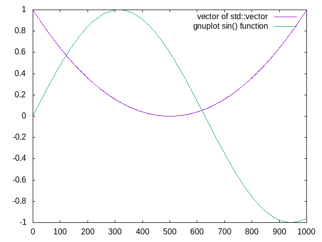

Note that the file will be in use, so we should close the `cling` session, if we want to delete the generated chart.